# Red Wine Analysis

### 5. Analysing Alcohol vs Residual Sugar

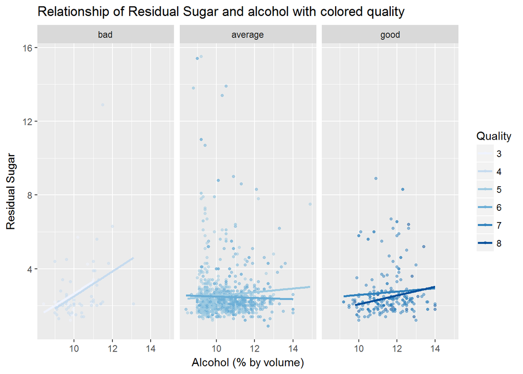

No such correlation between residual sugar and quality.

### 6. Analysing Alcohol vs Sulphur Dioxide

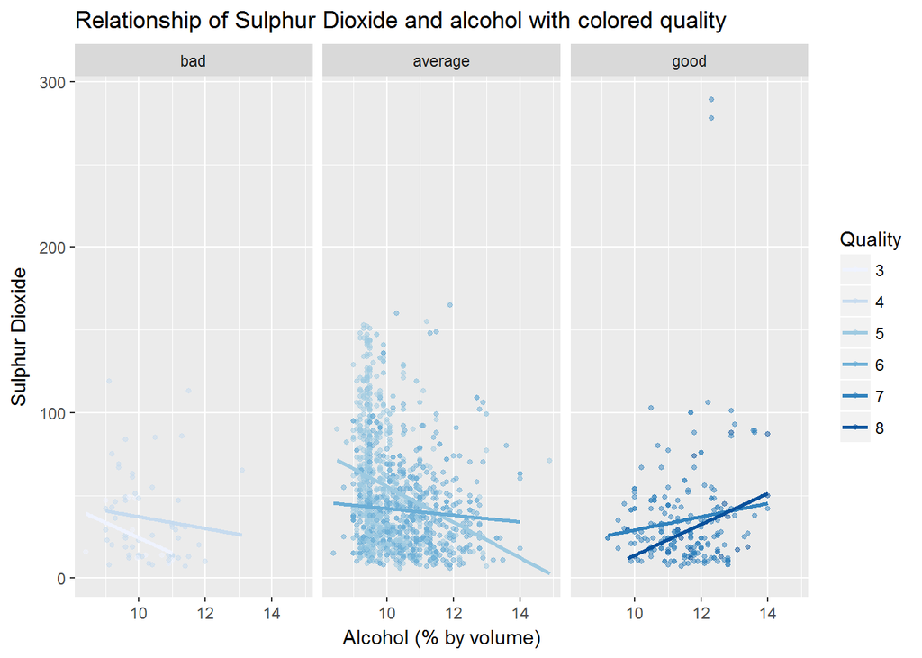

This is also the same. Lower Sulphur Dioxide seems to produces better quality wine.

### 7. Linear Modelling

Now we would develop a linear model by regressing strongly correlated variable with Quality.

```
##
## Calls:
## m1: lm(formula = as.numeric(quality) ~ alcohol, data = redWineQuality)
## m2: lm(formula = as.numeric(quality) ~ alcohol + sulphates, data = redWineQuality)
## m3: lm(formula = as.numeric(quality) ~ alcohol + sulphates + volatile.acidity,
##     data = redWineQuality)
## m4: lm(formula = as.numeric(quality) ~ alcohol + sulphates + volatile.acidity +
##     citric.acid, data = redWineQuality)
## m5: lm(formula = as.numeric(quality) ~ alcohol + sulphates + volatile.acidity +
##     citric.acid + fixed.acidity, data = redWineQuality)
## m6: lm(formula = as.numeric(quality) ~ alcohol + sulphates + volatile.acidity +
##     citric.acid + fixed.acidity + pH, data = redWineQuality)
##
## ========================================================================================================
##                          m1            m2            m3            m4            m5            m6
## --------------------------------------------------------------------------------------------------------
##   (Intercept)          -0.125        -0.625***      0.611**       0.646**       0.202         1.069
##                        (0.175)       (0.177)       (0.196)       (0.201)       (0.224)       (0.575)
##   alcohol               0.361***      0.346***      0.309***      0.309***      0.320***      0.327***
##                        (0.017)       (0.016)       (0.016)       (0.016)       (0.016)       (0.017)
##   sulphates                           0.994***      0.679***      0.696***      0.701***      0.688***
##                                      (0.102)       (0.101)       (0.103)       (0.103)       (0.103)
##   volatile.acidity                                 -1.221***     -1.265***     -1.343***     -1.336***
##                                                    (0.097)       (0.113)       (0.113)       (0.113)
##   citric.acid                                                    -0.079        -0.469***     -0.502***
##                                                                  (0.104)       (0.137)       (0.138)
##   fixed.acidity                                                                 0.057***      0.045**
##                                                                                (0.013)       (0.015)
##   pH                                                                                         -0.251
##                                                                                              (0.153)
## --------------------------------------------------------------------------------------------------------
##   R-squared             0.227         0.270         0.336         0.336         0.344         0.345
##   adj. R-squared        0.226         0.269         0.335         0.334         0.342         0.343
##   sigma                 0.710         0.690         0.659         0.659         0.655         0.655
##   F                   468.267       294.988       268.912       201.777       167.023       139.780
##   p                     0.000         0.000         0.000         0.000         0.000         0.000
##   Log-likelihood    -1721.057     -1675.142     -1599.384     -1599.093     -1589.648     -1588.303
##   Deviance            805.870       760.894       692.105       691.852       683.728       682.578
##   AIC                3448.114      3358.284      3208.768      3210.186      3193.297      3192.605
##   BIC                3464.245      3379.793      3235.654      3242.448      3230.937      3235.622
##   N                  1599          1599          1599          1599          1599          1599
## ========================================================================================================
```

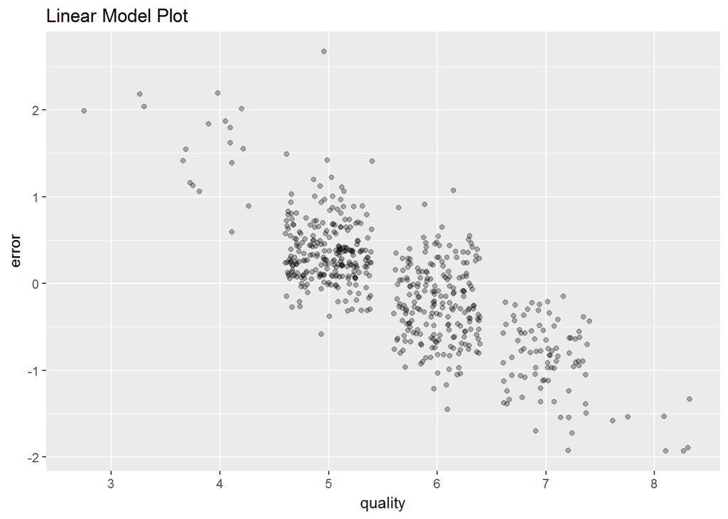

### ——————————————————————————————————————

### ——————————————————————————————————————

## 8. Analysis of Multivariate Plots

### 1. Inference

The Factors seem to have a say in good quality wine production are: 1. High Alcohol and Sulaphate. 2. Citric Acid (weak correlation) also plays a part in improving the wine quality.

### 2. Prediction Analysis

The Statistical Analysis we can infer: 1. From the linear regression we can infer that there was a low R dquared value in the models. 2. Alcohol contributes most of the wine quality that is also 22%. 3. From the very begining we can recollect that the dataset comprised of large no of Average quality wines. This proved to be a deciding factor in our analysis. The data was biased to some extent and hence it never really produced a good statistical result.

### ——————————————————————————————————————

### ——————————————————————————————————————

## 9. Final Plots and Summary

### Plot 1 - Plotting Alcohol to determine wine quality

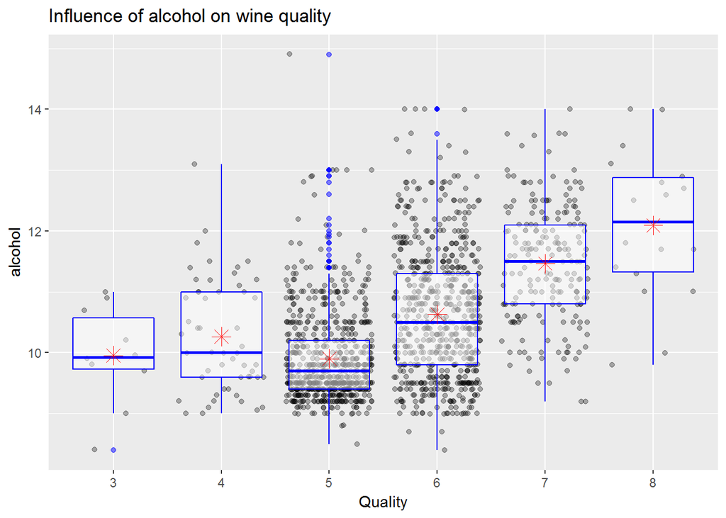

From this plot we can infer that higher the alcohol percentage, the better is the wine quality. There is a biasing in data gathering in this dataset. Most of the data is of average wine quality. Hence the prediction also going to hold some biasing in it. Previously from our linear model test, we saw that alcohol alone contributes to about 22% in the variance of the wine quality. So alcohol is not the only factor which is responsible for the improvement in Wine Quality.

### Plot 2 - Plotting Alcohol and PH to determine wine quality

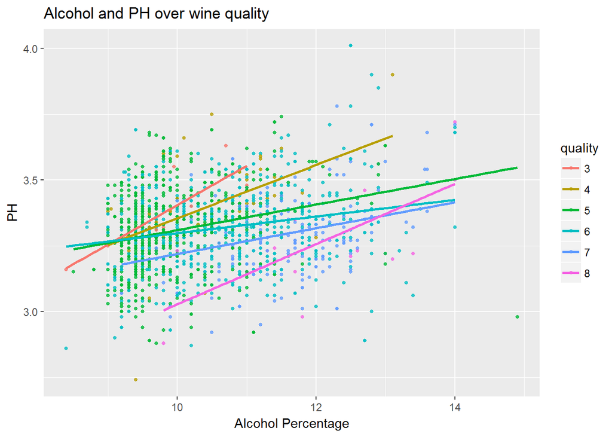

Low pH and high Alcohol percentage seems to produce better wines.

### Plot 3 - Plotting Alcohol and Sulphates to determine wine quality

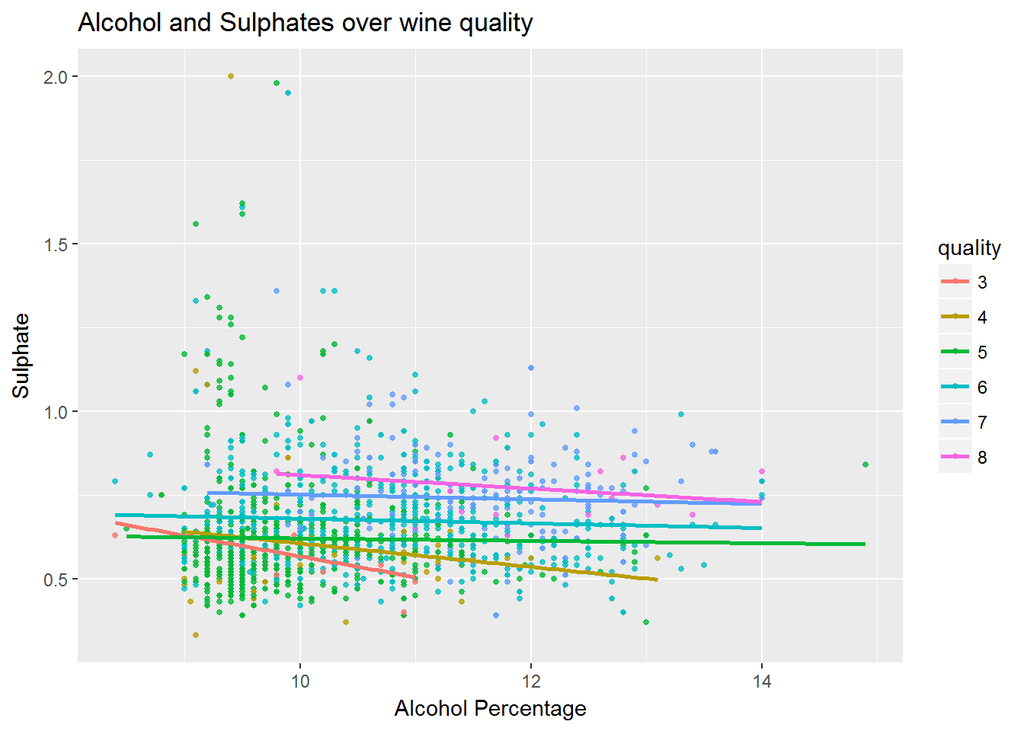

In this plot, we see that the good quality wines have high values for both Alcohol percentage and Sulphate concentration implying that High alcohol contents and high sulphate concentrations together seem to produce better wines. There is also a very slight downwards slope which indicates that percentage of alcohol is slightly greater than the concentration of Sulphate for producing good quality wines.

### Plot 4 - Plotting Linear model Error against Quality

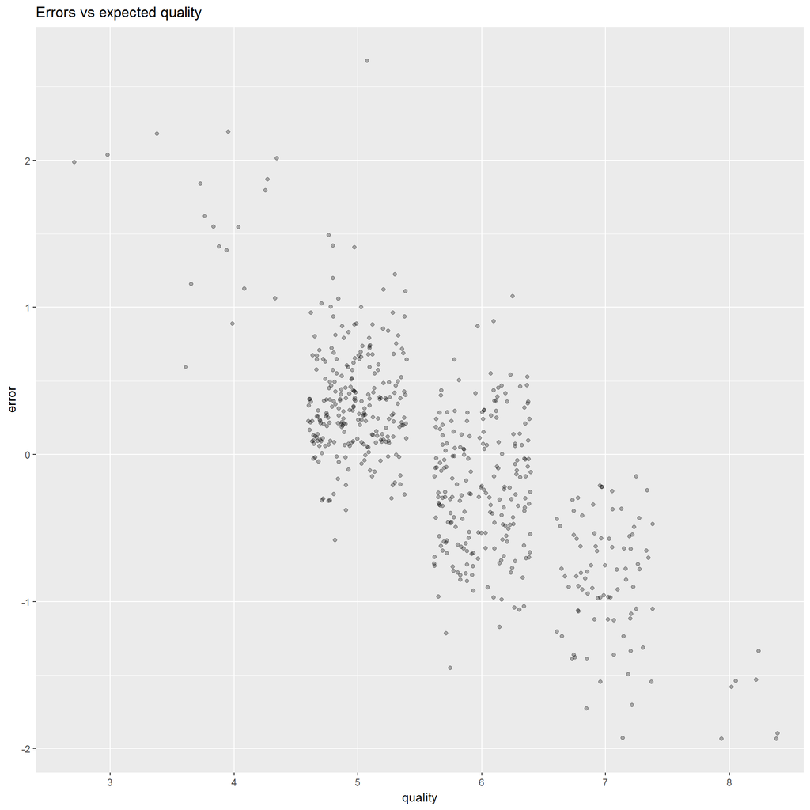

This plot shows the error is much more dense in the ‘Average’ quality section than the ‘Good’ and the ‘Bad’ quality wines. It also shows how the data is baised towards error prone prediction. Our dataset comprises mainly of ‘Average’ quality wines. The linear model with the R squared value for ‘PH’ could only explain around 35% change in quality. So this dataset is not at all perfect for good and bad quality wine prediction.

### ——————————————————————————————————————

### ——————————————————————————————————————

## 10. Reflections

While regressing this data we were not confident enough about getting a higher confidence level and building a prediction model for differnent Qualities of wines. As the dataset was too biased having large number of ‘Average’ readings and less number of ‘Good’ and ‘Bad’ readings, hence building an accurate prediction model around this data set became quite difficult.

First we started off with plotting different variables to see their distribution and Univariate relationships between them. Some of them showed positive skewness while density and pH showed almost normal distribution. After that we slowly added other variables present the dataset one by one in bivariate plots to analysed their effect in determining wine quality. The factors which affected the quality of the wine were mostly Alcohol percentage, Sulphate and Acid concentrations.

During analysing bivariate plots we saw that higher the concentration of citric acid greater is the wine quality is some cases. But quality of some variety of wines does not depend on citric acid. Hence it is not advisable to draw conclusion without analysis the particular dataset.

Lastly we plot multivariate plots to see if there were some combinations of variables which together affected the overall quality of the wine. We concluded that density did not play a part in improving wine quality.

So maybe for future analysis, a dataset about Red Wines with more complete information and unbiased readings would help us to draw better conclusions and build models more effectively. Not only that, if we are able to survey on the Red wine quality and collect the ratings from different people, then we would have some real life variety data to deal with. We might be able to apply some data science algorithm on them and be able to perform a much better analysis.